# Statistical Modeling and Data Visualization

Susan VanderPlas

# Outline

- Introduction
- Consulting Project:  
  Predicting power plant performance with increased maintenance cycle length
- Other Projects

# Introduction

# About Me

PhD in Statistics (2015*)  
MS in Statistics (2011)

[figure not shown]

BS in Applied Mathematical Sciences and Cognitive Psychology (2009)

[figure not shown]

# Statistical Interests

- Modeling
- Bayesian statistics
- Data mining
- Visualization
- Simulation
- Nonparametric statisics
- Engineering statistics

# Research

- Modeling material structure and composition  
  Nonparametric statistics for Atom Probe Tomography data  
  (MS research, with ISU Material Science & Engineering)
- Evaluating road safety (with Iowa Dept. of Transportation)
- Exploring perception of statistical graphics (PhD research)
- Analysis of soybean genomics (with USDA)

# Teaching

- R workshops for the Iowa State community
- Statistics for Research Workers (engineering and social science sections) - use of SAS and JMP for statistical analysis
- Business Statistics II - use of JMP for statistical analysis

# Statistical Philosophy

- Understand the dataset through exploratory analysis
  - graphical summaries
  - summary statistics
  - identify record errors, data artifacts, other issues that may affect modeling
- Appropriately model the data
- Communicate model results and implications clearly
  - graphics
  - simulated model predictions

# Modeling Plant Reliability Under New Maintenance Conditions

# Data Description

- Monthly capacity factor

  $CF = \frac{Power\ Produced}{Max\ Capacity}$

  Equivalently, Effective Full Power Days Lost (EFPDL)

  $EFPDL = Days * (1-CF/100)$
- Maintenance approx. every 18 months (21-60 days)
- Reduced power for 2-4 days (every 3 months) to adjust fuel distribution
- Occasional shutdowns (2-30+ days) to maintain critical systems

This presentation shows data simulated using knowledge of plant constraints.  
Simulated data is extremely similar to observed data in average capacity factor, autocorrelation, and other properties.

# Data

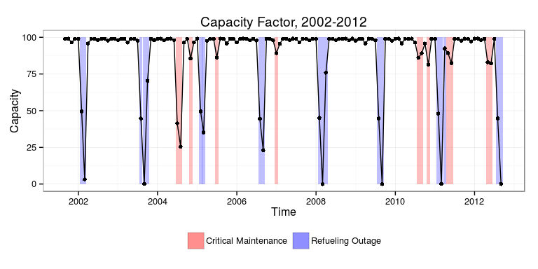

# Diagnostics

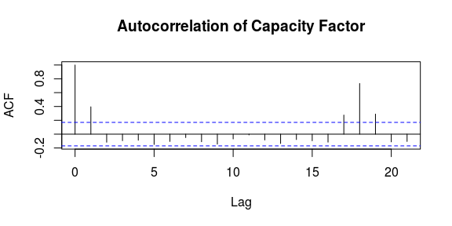

# Options

### Wear Cycle

Assumption: More wear at some points

- Stratified sampling (Month 1-12, 13-outage), months 18-22 not stratified
- Uniform wear throughout the cycle: Completely random sample

### Wear From Increased Cycle Length

Assumption: Extra wear for last 6 months of the cycle

- 23 months operation (+ 2 months outage)
- Normal Wear: 22 months operation (+ 2 months outage)

# Results

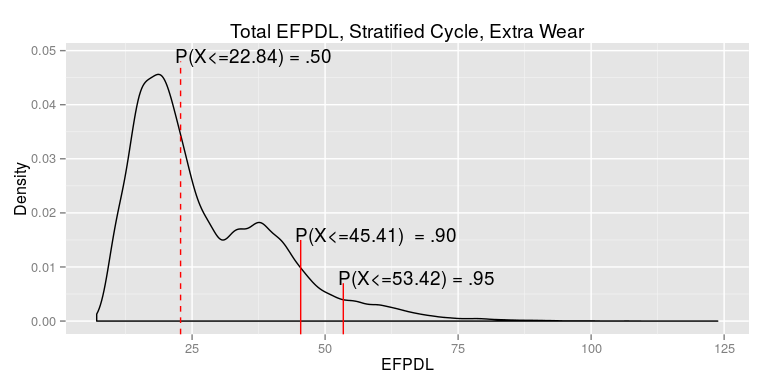

# Results

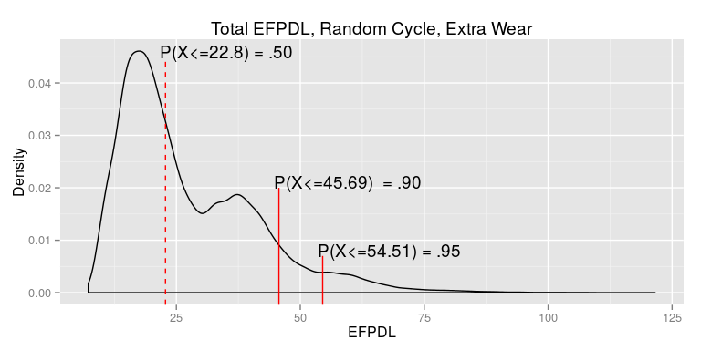

# Results

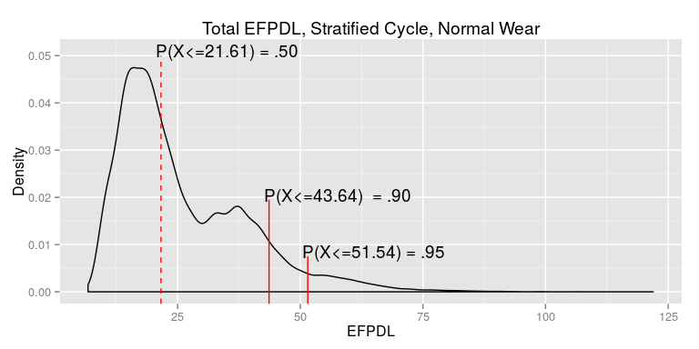

# Results

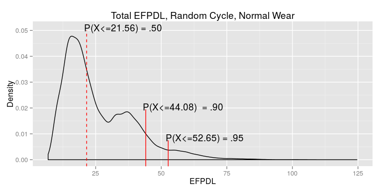

# Conclusions

- 4 models don’t differ *much* in predictions
- Model accurately predicted 2012-2014 cycle within 1 day EFPDL
- Predictive distribution shows results in an intuitive fashion
- Model is highly customizable to different estimation needs
  - Exclude long unplanned outages (for use in fuel planning)
  - Modify sampling distribution (for a more conservative estimate)

# Other Projects

# Research

- Dissertation
  - Examine illusions which affect perception of variability in statistical plots  
    2014 ASA Student paper award, statistical grahics section
  - Assess visual skills required for reading statistical graphics
  - Understand the interaction between (and hierarchy of graphical features)
- Visualization of soybean population genetic data

# Computation

- [Animint](https://github.com/tdhock/animint) - Extends the ggplot2 implementation of the grammar of graphics to interactive plots
- Shiny applets - Interactive web applets for data display
- Data Aggregation
  - Craigslist ads
  - OkCupid
  - Location-based energy prices